# 第7回 整理集計②：個票集計

## 平均貯蓄率 20.0% の裏の D

[figure not shown]

**サンプルデータ**：ミニの 7 世帯の貯蓄率  
（lec7-exercise.xlsx「個票」の W4:W10）

平均だけでは、端にいる世帯は消える  
個票なら、名指しで数えられる

## 貯蓄率がマイナスの世帯の数

1. **打つ**：P27 に次の式で Enter  
   `=COUNTIF(ミニ[貯蓄率],"<0")`
2. **見る**：P27 が 1  
   `"<0"` は 0 より小さい、の条件
3. **確かめる**：W7 の -10.0  
   数えた 1 世帯は D

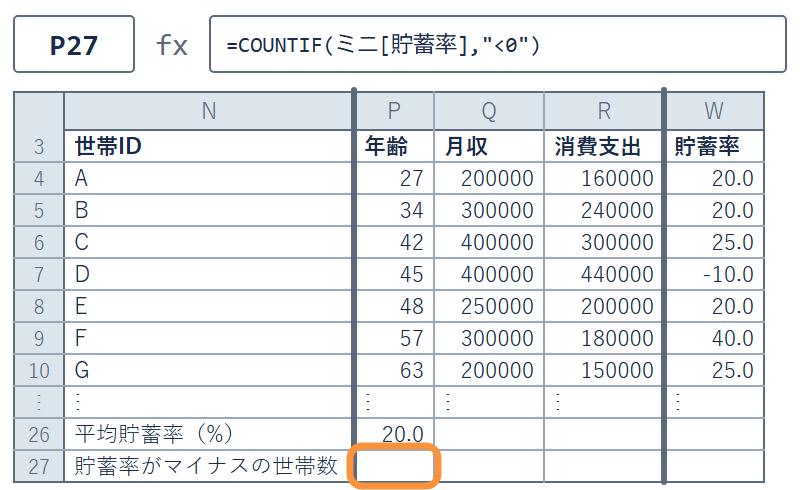

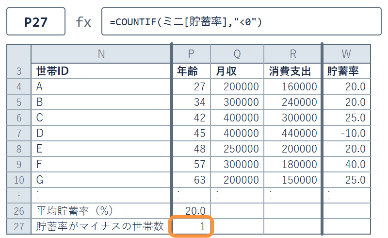

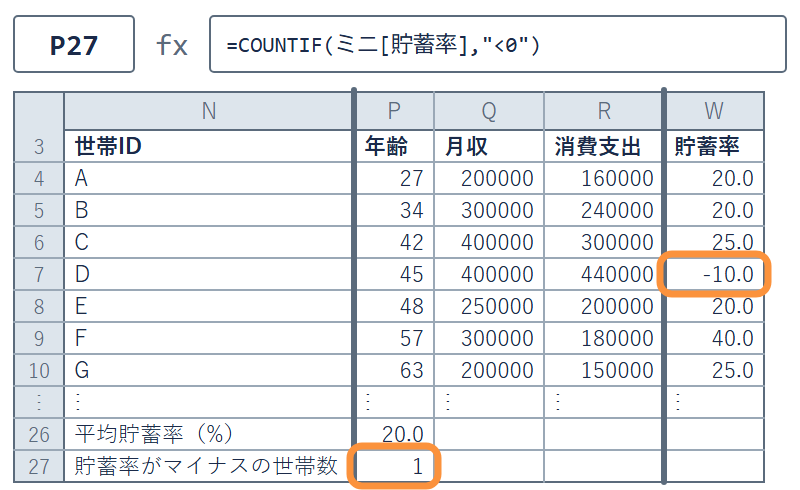

✋ 比べる記号つきの条件は `"` でくくる。P27 が 1 なら再生に戻る

## 100 世帯の 5 階級の式

今度は 100 世帯の個票で、同じ 3 本の式を打つ  
変わるのはテーブル名と条件のセル（N30〜N34）だけ

| セル | 式（20代の行） |
| --- | --- |
| O30 | `=COUNTIF(個票[年齢階級],N30)` |
| P30 | `=SUMIF(個票[年齢階級],N30,個票[貯蓄])` |
| Q30 | `=AVERAGEIF(個票[年齢階級],N30,個票[貯蓄])` |

**サンプルデータ**：架空の 100 世帯（lec7-exercise.xlsx「個票」の A1:L101）

## 個票の 5 階級の表

1. **打つ**：O30・P30・Q30 に  
   p.50 の 3 本の式（N30 を指す）
2. **写す**：O30〜Q30 を 34 行目まで下へ  
   O35 に `=SUM(O30:O34)`
3. **見る**：O35 が 100 で数え落としなし  
   40代は 16,590 ÷ 24 ＝ 691.25

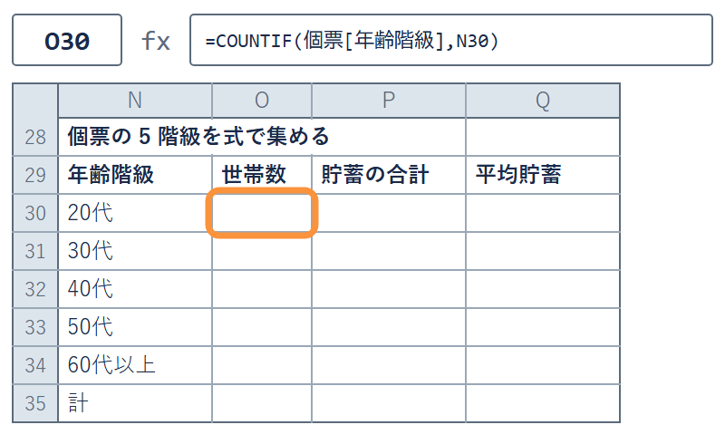

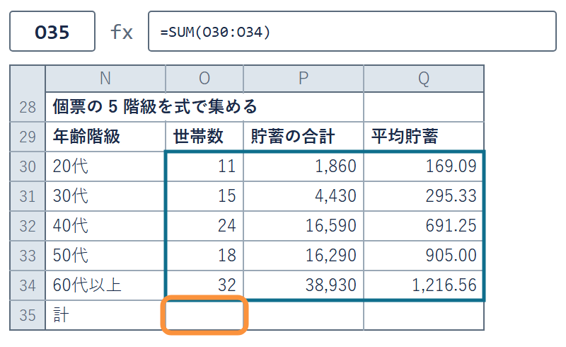

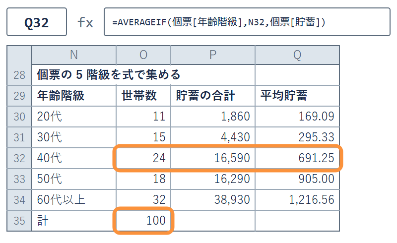

✋ 動画を止めて STEP 1〜3 を進め、O35 が 100 なら再生に戻る

## たしかめ 100 世帯の赤字の世帯

100 世帯の平均貯蓄率は 22.5%（このあと自分の式で出す）  
貯蓄率がマイナス（赤字）の世帯は、何世帯あるか

**1 1 世帯もない**

2 少しある  
（数世帯）

**3 半分近くある**

1 つ決めてから先へ。答えは、自分の式で出す

## 個票の貯蓄率と赤字の数

1. **打つ**：L2 に貯蓄率の式で Enter  
   （ミニの W4 と同じ式・p.46）
2. **打つ**：P37 に  
   `=AVERAGE(個票[貯蓄率])`
3. **打つ**：P38 に  
   `=COUNTIF(個票[家計判定],"赤字")`
4. **打つ**：P39 に  
   `=COUNTIF(個票[貯蓄率],"<0")`

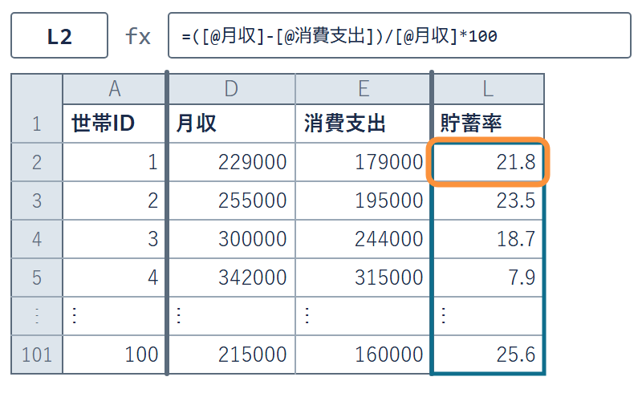

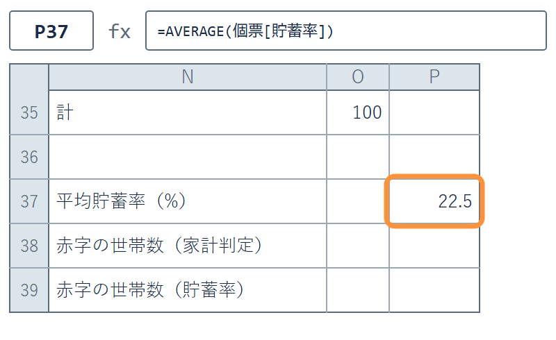

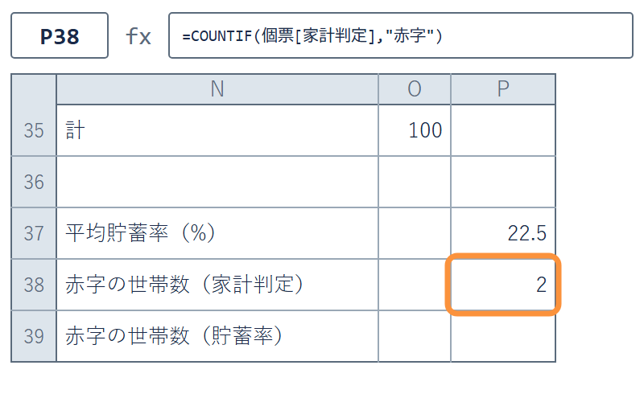

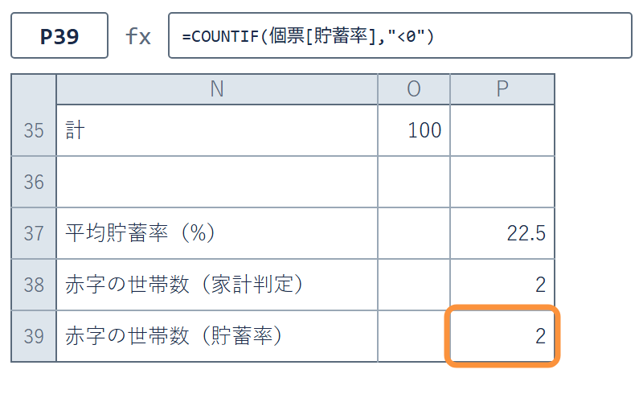

✋ 動画を止めて STEP 1〜4 を進め、P38 と P39 が 2 なら再生に戻る

## 貯蓄率の昇順の並べ替え

1. **並べる**：L1 の ▼ から「昇順」  
   貯蓄率の小さい順になる
2. **読む**：2 行目が世帯51 で  
   3 行目が世帯29  
   P40 に 51 を、P41 に 29 を打つ
3. **戻す**：A1 の ▼ から「昇順」  
   世帯ID の順に戻る

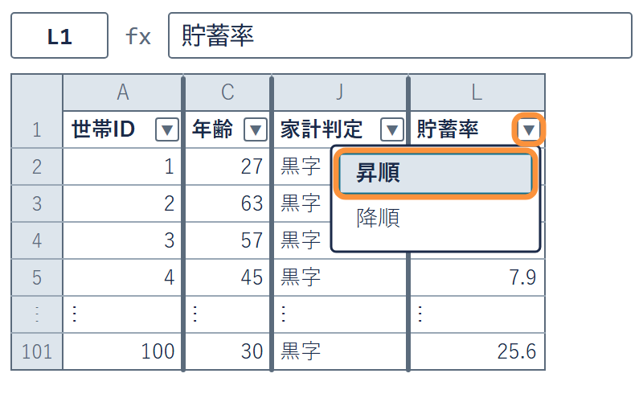

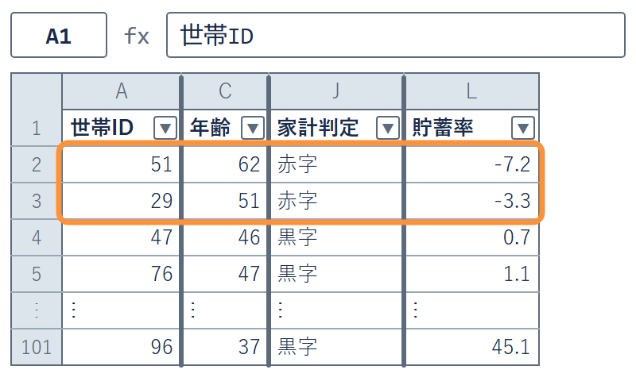

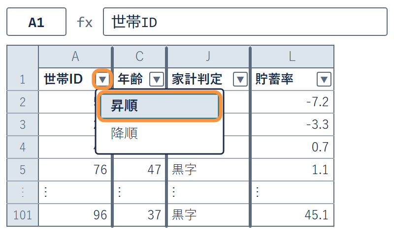

✋ 動画を止めて STEP 1〜3 を進め、P40 と P41 を打ったら再生に戻る

## 平均 22.5% の裏の 2 世帯

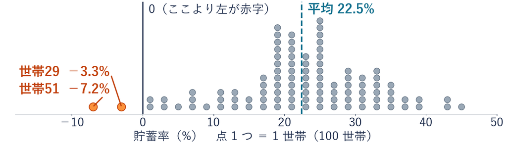

**サンプルデータ**：lec7-exercise.xlsx「個票」の L2:L101

たしかめの答えは 2 番。赤字は世帯51 と世帯29 の 2 世帯

## 平均と個票の役割

この回の要

平均を出しただけでは、赤字の 2 世帯は消える  
個票まで降りれば、端にいる世帯を名指しで数えられる

- **ミニ**：平均 20.0% の裏に、D（−10%）の 1 世帯
- **100 世帯**：平均 22.5% の裏に、世帯51（−7.2%）と世帯29（−3.3%）
- **名指しの道具**：COUNTIF で数え、昇順の並べ替えで上の行を読む

## 失敗例 引用符の無い条件

引用符なし  
`=COUNTIF(個票[貯蓄率],<0)`  
式が入らない  
（問題があると出る）

引用符あり  
`=COUNTIF(個票[貯蓄率],"<0")`  
→ **2** 世帯（赤字の数）

- **なぜ書きたくなるか**：IFS では `[@年齢]<30` と、くくらずに書いた
- **COUNTIF の条件**：`"<0"`・`"赤字"` のように、`"` でくくって渡す
- **セルを指す条件**：N30 はくくらない。くくると「N30」という字を探す

## 演習 7-2 貯蓄率 10% 未満

演習 7-2

貯蓄率が 10% 未満の世帯は、何世帯あるか

1. **作る場所**：答え欄の Y5 に COUNTIF の式を打つ
2. **変える所**：P39 の式の条件 1 か所（0 より小さい → 10 より小さい）
3. **考える問い**：何世帯か。式を打つ前に予想する  
   5 以下・6〜20・21 以上 のどれか
4. **書く**：Y5 は式のままでよい。出た数が提出する答え

✋ 動画を止めて 3 分。Y5 に数が出たら再生に戻る

## 演習 7-2 の答えの例

`=COUNTIF(個票[貯蓄率],"<10")` → **11** 世帯

- **Y5**：11 世帯で、予想の 6〜20 に入る
- **変えたのは**：`"<0"` の 0 を 10 に。式の残りは P39 と同じ
- **ちょうど 10% の世帯は無い**：`"<=10"` と書いても 11 世帯

## まとめ

- **条件つき集計**：条件に合う行だけを、COUNTIF で数え、  
  SUMIF で足し、AVERAGEIF で平均する
- **3 つの関係**：AVERAGEIF ＝ SUMIF ÷ COUNTIF
- **貯蓄率**：（月収 − 消費支出）÷ 月収 × 100（マイナスなら赤字）
- **名指し**：貯蓄率の昇順に並べると、端の世帯が上に来る

式 1 本で数え、平均の裏の 2 世帯を名指しできた。  
でも答えは、式が合っていてこそ  
別の道でも同じ数になるか。これを次のトピックで見る

経済データ入門

第7回 — Topic04

ピボットテーブルとクロス集計

同じ答えを、ドラッグだけでもう一度出す

## この回の道のりと「個票」シート

1

個票と集計表

2

名札を付ける

演習 7-1

年齢の 3 区分

3

条件で数える

演習 7-2

貯蓄率 10% 未満

4

ピボットで照合

演習 7-3

貯蓄率の低い年齢

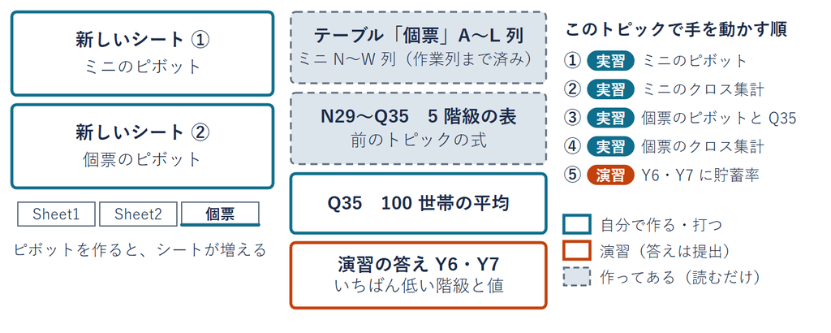

lec7-exercise.xlsx「個票」から、新しいシートにピボットを 2 つ

## 切り口ごとの式の書き直し

前のトピックで、5 階級の表を式 15 本で作った  
黒字と赤字に分けると、式は 30 本。全部書き直す  
見出しを枠に置くだけで、集計表を組み替えられないか

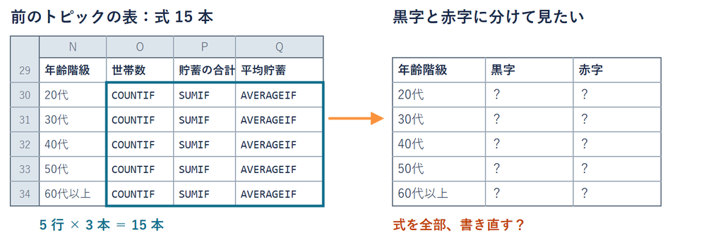

**サンプルデータ**：架空の 100 世帯の式の表  
（lec7-exercise.xlsx「個票」の N29:Q35）

## ミニの 7 行のピボット

[figure not shown]

**サンプルデータ**：ミニの 7 世帯  
（lec7-exercise.xlsx「個票」の N3:W10）

40代の 3 行が 1 行に集まり、合計は 1,800 で平均は 600

## ピボットテーブル

用語

**ピボットテーブル**：見出しを行・列・値の枠に置く集計表

- **できること**：式を書かずに、集計表を組み替える
- **行と列**：名札（年齢階級・家計判定）を置く枠。  
  行は縦に、列は横に並ぶ
- **値**：集計する数を置く枠。数の見出しは、まず合計
- **今回は**：行に年齢階級、値に貯蓄の平均。40代は 600

## ミニのピボットテーブル

1. **作る**：名前ボックスで N3 へ移り  
   挿入 → ピボットテーブル → OK
2. **置く**：年齢階級を行へ、  
   貯蓄を値へ  
   40代は合計の 1800  
   欄が見えないときは、  
   表の中をクリック
3. **変える**：値の枠の ▼ →  
   「値フィールドの設定」  
   平均を選び、  
   表示形式で小数 1 桁・桁区切り
4. **見る**：40代は 600.0  
   前のトピックの Q25 と同じ

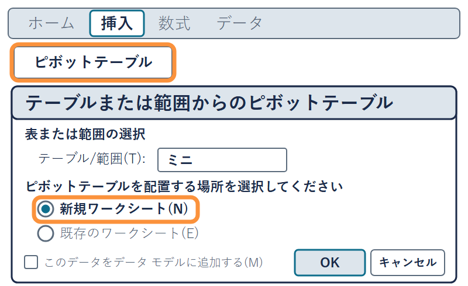

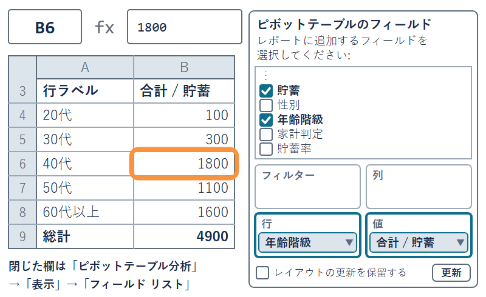

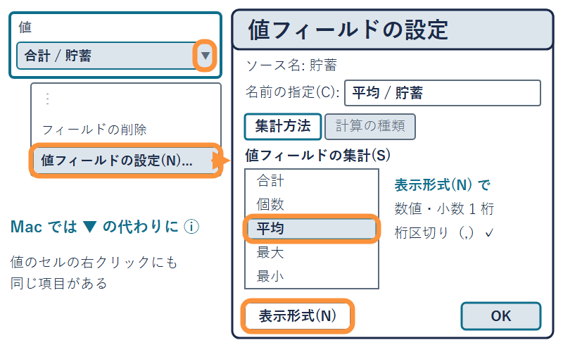

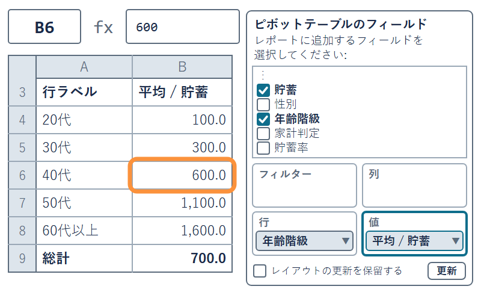

✋ 動画を止めて STEP 1〜4 を進め、40代が 600.0 なら再生に戻る

## 失敗例 更新し忘れたピボット

[figure not shown]

- **なぜ信じたくなるか**：自動で集計するので、手で書いた式より正確そう
- **直し方**：元の表を直したら、ピボットの中で右クリック →「更新」

式と並べておけば、ずれに気づける

## ミニの家計判定の列

[figure not shown]

**サンプルデータ**：ミニの 7 世帯  
（lec7-exercise.xlsx「個票」の N3:W10）から作ったピボット

## たしかめ 40代の赤字の世帯

40代の平均貯蓄は、黒字 750.0・赤字 300.0  
40代では、赤字の世帯は黒字の世帯より貯蓄が少ない、と言えるか

**1 言える**

**2 この表だけでは言えない**

1 つ決めてから先へ。答えは、自分のピボットの個数で出す

## ミニのクロス集計

1. **置く**：家計判定を  
   「列」の枠へドラッグ  
   40代は黒字 750.0・赤字 300.0
2. **変える**：値の枠の ▼ →  
   「値フィールドの設定」→ 個数
3. **見る**：40代は黒字 2・赤字 1  
   赤字の 1 世帯は D

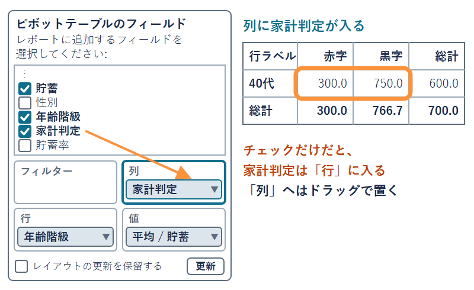

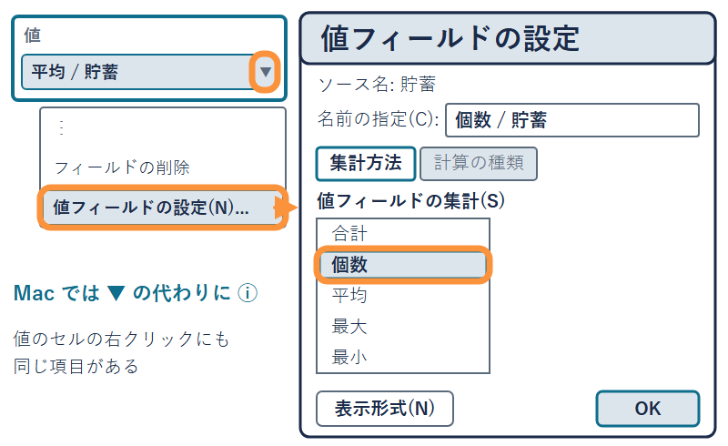

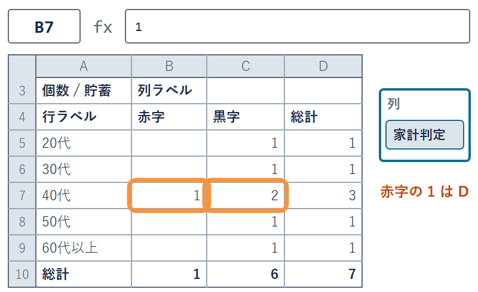

✋ 動画を止めて STEP 1〜3 を進め、40代の赤字が 1 なら再生に戻る

## クロス集計

用語

**クロス集計**：2 つの名札を縦と横に組んだ集計表

- **今回は**：縦に年齢階級、横に家計判定。40代の赤字のマスは D の 1 世帯
- **たしかめの答え**：2 番。赤字の 300.0 は D 1 世帯の貯蓄

作法

マスの数字を読む前に、そのマスの世帯数を見る

## 100 世帯の 2 通りの集計

今度は 100 世帯の個票で、同じ手順を  
ピボットの答えを、前のトピックの式の表と 1 行ずつ並べる

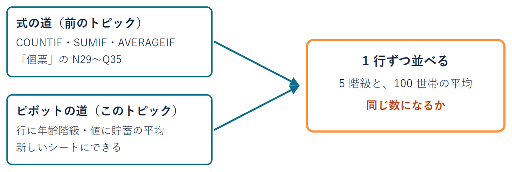

**サンプルデータ**：架空の 100 世帯（lec7-exercise.xlsx「個票」の A1:L101）

## 個票のピボットテーブル

1. **作る**：「個票」シートに戻り  
   A2 を選び  
   挿入 → ピボットテーブル → OK
2. **置く**：年齢階級を行、貯蓄を値へ  
   平均にし、小数 1 桁・桁区切り
3. **見る**：40代のセルを選ぶ  
   表示は 691.3 で数式バーは 691.25
4. **打つ**：「個票」シートの Q35 に  
   `=AVERAGE(個票[貯蓄])` → 781.00

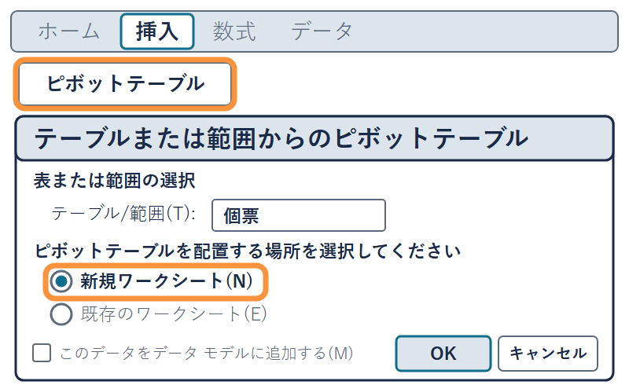

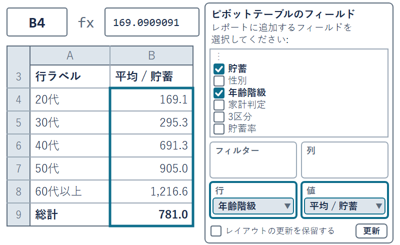

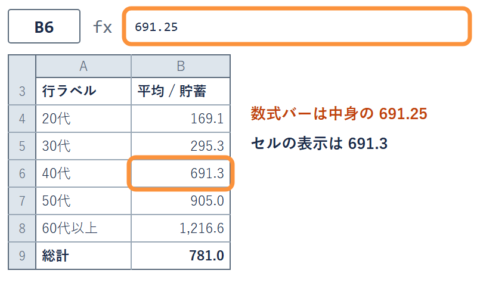

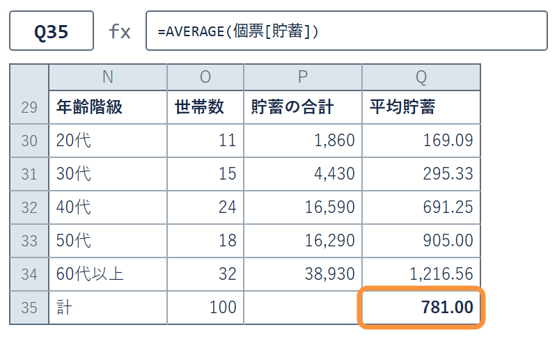

✋ 動画を止めて STEP 1〜4 を進め、総計が 781.0 なら再生に戻る

## 式とピボットの照合

|  | 20代 | 30代 | 40代 | 50代 | 60代以上 | 総計 |
| --- | --- | --- | --- | --- | --- | --- |
| 式（Q 列） | 169.09 | 295.33 | 691.25 | 905.00 | 1,216.56 | 781.00 |
| ピボット | 169.1 | 295.3 | 691.3 | 905.0 | 1,216.6 | 781.0 |

型

2 通りで同じ数なら、式の書き間違いは無い  
どの世帯を数えたかは、自分で確かめる

桁が違うのは表示だけ。40代の中身はどちらも 691.25

## 個票のクロス集計

1. **置く**：家計判定を  
   「列」の枠へドラッグ  
   総計は赤字 1,110.0・黒字 774.3
2. **変える**：値の枠の ▼ →  
   「値フィールドの設定」→ 個数
3. **見る**：赤字は 50代 1・60代以上 1  
   20代〜40代の赤字のマスは空

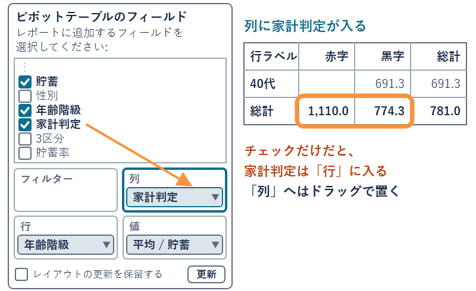

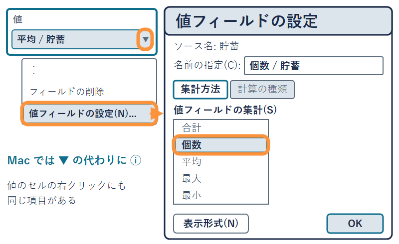

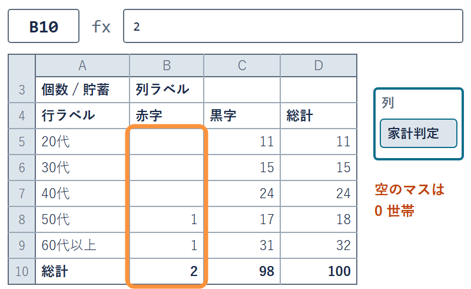

✋ 動画を止めて STEP 1〜3 を進め、赤字の総計が 2 なら再生に戻る

## 赤字の 2 世帯のマス

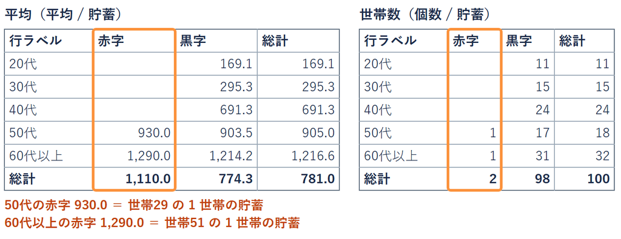

**サンプルデータ**：架空の 100 世帯  
（lec7-exercise.xlsx「個票」の A1:L101）から作ったピボット

赤字の 1,110.0 は 2 世帯だけの平均  
1 世帯のマスは、その世帯の貯蓄そのもの

## 演習 7-3 貯蓄率の低い年齢

演習 7-3

平均貯蓄率がいちばん低い年齢階級は、どこか

1. **作る場所**：個票のピボット。列の家計判定は、一覧のチェックを外して消す
2. **変える所**：貯蓄のチェックを外し、貯蓄率にチェック  
   集計は平均に選び直し、表示形式で小数 1 桁
3. **考える問い**：平均貯蓄がいちばん少ないのは 20代。貯蓄率でも 20代か  
   1 20代・2 40代・3 60代以上 から予想する
4. **書く**：Y6 に年齢階級、Y7 にその値（「個票」シートの答え欄）

✋ 動画を止めて 4 分。Y6 と Y7 を打ったら再生に戻る

## 演習 7-3 の答えの例

いちばん低いのは 40代の **17.4**（予想の 2 番）

| 年齢階級 | 20代 | 30代 | 40代 | 50代 | 60代以上 | 総計 |
| --- | --- | --- | --- | --- | --- | --- |
| 平均 / 貯蓄率 | 27.4 | 27.3 | 17.4 | 23.5 | 21.7 | 22.5 |

- **Y6・Y7**：40代と 17.4
- **20代は**：平均貯蓄はいちばん少ないが、貯蓄率はいちばん高い
- **総計の 22.5**：前のトピックの P37（100 世帯の平均貯蓄率）と同じ

## まとめ

- **ピボットテーブル**：見出しを行・列・値に置くだけの集計表
- **照合**：式と同じ数なら、書き間違いは無い
- **更新**：元の表を直したら、ピボットも更新
- **クロス集計**：2 つの名札を縦と横に組み、マスごとに集計する
- **世帯数を先に**：マスの数字は、そのマスの世帯数とセットで読む

式とピボットの 2 通りで同じ数に着き、切り口を組み替えられた  
平均の 1 行の裏には、名指しできる世帯がいる  
個票に降りて、名札を付けて、数えて、確かめる  
この 4 段が、1 冊のブックにそろった